# HW05

Chongdan Pan

2022/2/12

### Problem 1

1. $$E(0.6R_1+0.4R_2)=0.6E(R_1)+0.4E(R_2)=0.6 * 0.03 + 0.4 * 0.04=0.034\\
   Var(0.6R_1+0.4R_2)=0.36Var(R_1)+0.16Var(R_2)+0.48Cov(R_1, R_2)\\
   Var(0.6R_1+0.4R_2)=0.36\times0.04^2+0.16\times0.06^2+0.48*0.5*0.04*0.06=0.001728$$
2. The variance is
   $$Var(w\cdot R_1+(1-w)R_2)=0.0016w^2+0.0036(1-w)^2+2w(1-w)*0.0012$$
   To minimize it, we need to calculate its derivative, which is
   $$2w\cdot0.0016-2(1-w)\cdot0.0036+2(1-w)\cdot0.0012-2w\cdot0.0012$$
   When $w=\frac{6}{7}$, since the second derivative is positive, we have the minimized variance.
3. For the multi-variate normal distribution

```r
V = Inf
W = 0
for(w in seq(0, 1, 0.05)){
  mean <- w * 0.03 + (1-w) * 0.04
  var <- (w * 0.04) ^ 2 + ((1-w) * 0.06) ^ 2 + 2 * w * (1-w) * 0.5 * 0.04 * 0.06
  VaR <- - 1e6 * qnorm(0.005, mean, var ** 0.5)
  if(VaR<V){
    V <- VaR
    W <- w
  }
}
W
```

```
## [1] 0.8
```

4. For the multi-variate t-distribution

```r
V = Inf
W = 0
q = qt(0.005, df=6)
for(w in seq(0, 1, 0.01)){
  mean <- w * 0.03 + (1-w) * 0.04
  lambda <- sqrt((4 / 6) *((w * 0.04) ^ 2 + ((1-w) * 0.06) ^ 2 + 2 * w * (1-w) * 0.5 * 0.04 * 0.06))
  VaR <- - 1e6 * (mean + (q * lambda))
  if(VaR<V){
    V <- VaR
    W <- w
  }
}
W
```

```
## [1] 0.81
```

### Problem 2

1. $$C(u_1, u_2)=P(F_X(x)\leq u_1,F_Y(y)\leq u_2)=P(F_X(x)\leq u_1,F_X(x)\leq u_2)\\
   C(u_1, u_2)=\min(u_1, u_2)$$
2. $$C(u_1, u_2)=P(F_X(x)\leq u_1,F_Z(z)\leq u_2)\\
   C(u_1, u_2)=P(F_X(x)\leq u_1,1-F_X(\sqrt[3]z)\leq u_2)\\
   C(u_1, u_2)=\begin{cases}u_1+u_2-1 &u_1+u_2\geq1\\0 & u_1+u_2<1\end{cases}$$

### Problem 3

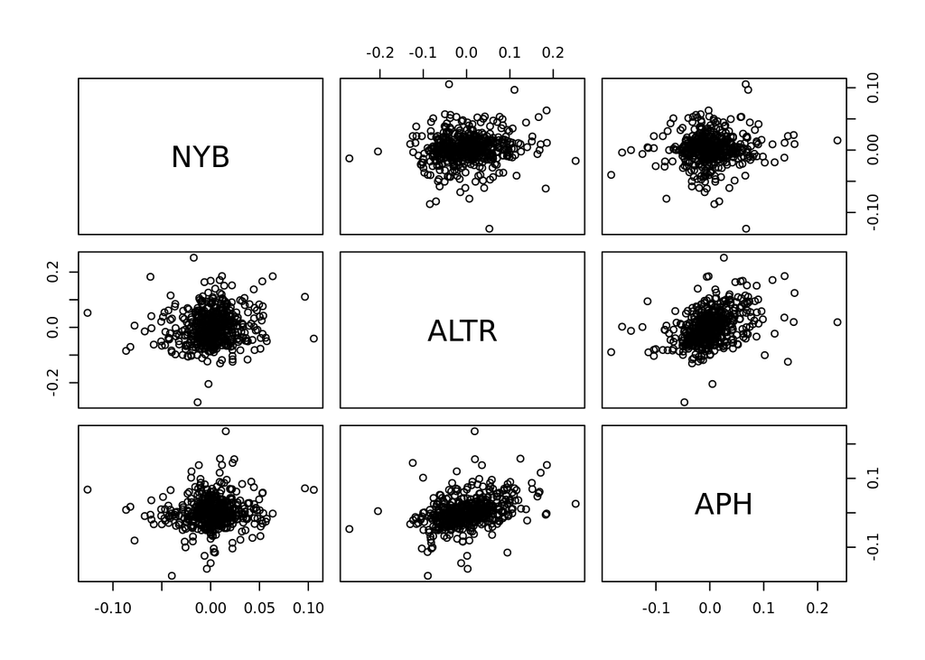

```r
Data = read.csv("midcapD.csv",header=TRUE)
Mid_Returns = Data[,c(5,6,7)]
plot(Mid_Returns)
```

It’s hard to see correlations from the scatter plot intuitively. But it looks like that there is a linear relationship between ALTR and APH. We can validate it through R.

|  | NYB | ALTR | APH |
| --- | --- | --- | --- |
| NYB | 1 | 0.1155 | 0.0754 |
| ALTR | 0.1155 | 1 | 0.3814 |
| APH | 0.0754 | 0.3814 | 1 |

Based on the result, it turns out all stocks have a positive correlation coefficient and it’s larger for APH and ALTR. In addition, all stocks is slightly skewed. NYB and APH has a high kurtosis, implying that they may have a heavy tail.

|  | NYB | ALTR | APH |
| --- | --- | --- | --- |
| skewness | -0.348 | 0.274 | 0.414 |
| kurtosis | 3.66 | 1.32 | 4.04 |

2. The return have following mean vector and covariance matrix for multivariate normal distribution

|  | NYB | ALTR | APH |
| --- | --- | --- | --- |
| mean | 1.687e-3 | 1.488e-3 | 1.612e-3 |

[output not shown]

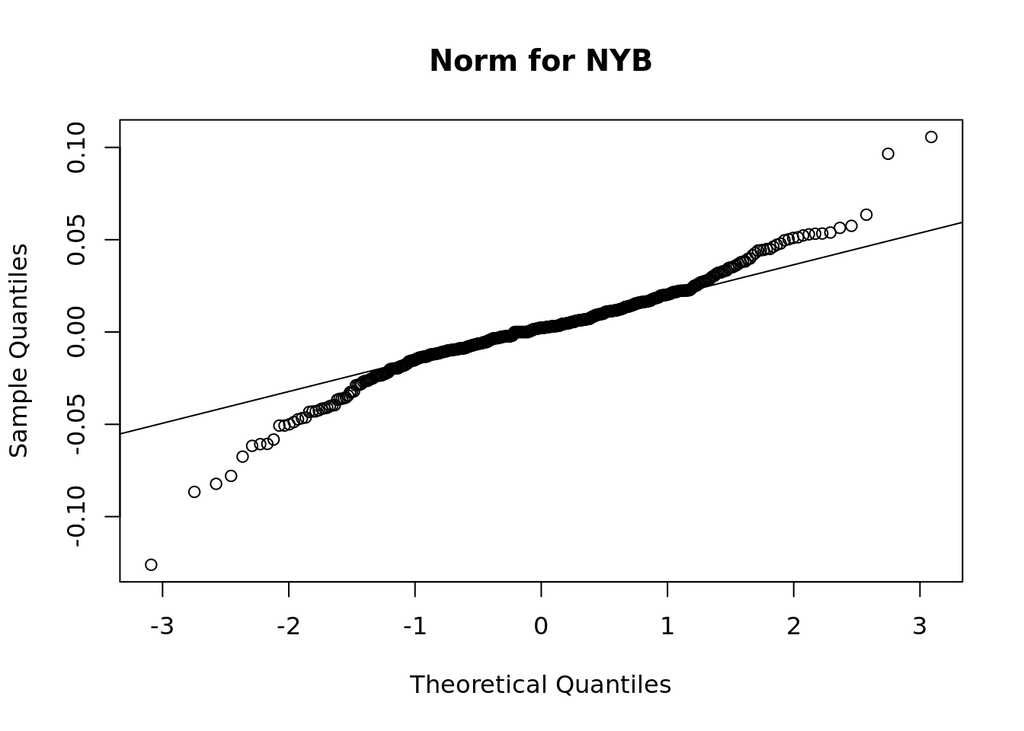

```r
qqnorm(Mid_Returns$NYB, main="Norm for NYB")
qqline(Mid_Returns$NYB)
```

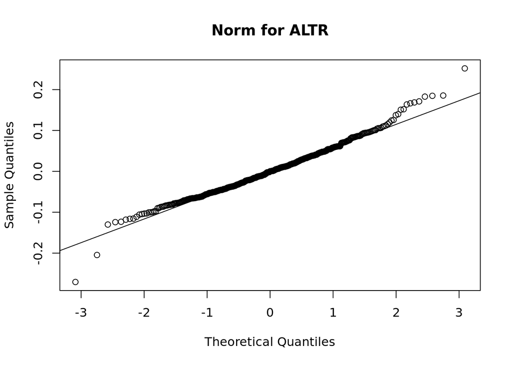

```r
qqnorm(Mid_Returns$ALTR, main="Norm for ALTR")
qqline(Mid_Returns$ALTR)
```

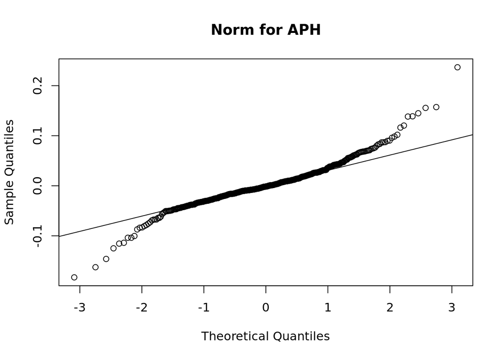

```r
qqnorm(Mid_Returns$APH, main="Norm for APH")
qqline(Mid_Returns$APH)
```

It turns out that all return have a heavier tail than normal distribution, implying that we need to use a heavy tail for fitting. ALTR has a relative thin tail, conforming the empirical kurtosis from previous section. For APH and NYB, it looks like that APH’s tail is not long heavy, but also very long.

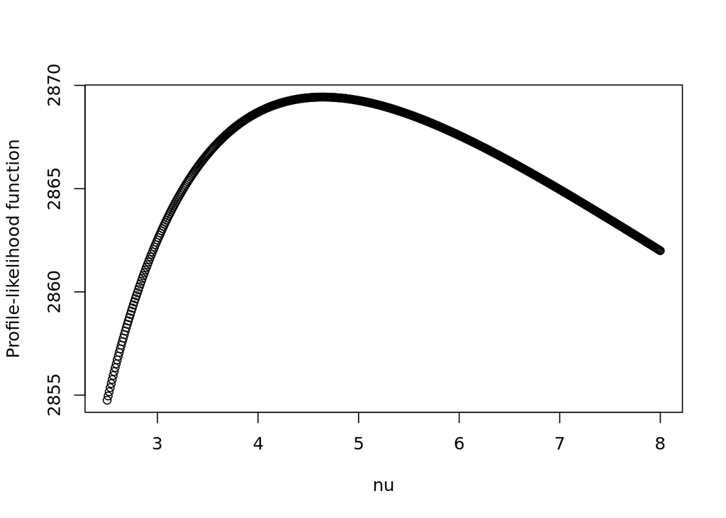

```r
library(mnormt)
library(MASS)
df = seq(2.5, 8, 0.01)
n = length(df)
loglik_max = rep(0, n)
for(i in 1:n){
  fit = cov.trob(Mid_Returns, nu=df[i])
  mu = as.vector(fit$center)
  sigma = matrix(fit$cov, nrow=3)
  loglik_max[i] = sum(log(dmt(Mid_Returns, mean=fit$center, S=fit$cov, df=df[i])))
}
plot(df, loglik_max, xlab="nu", ylab="Profile-likelihood function")
```

```r
nu = df[which.max(loglik_max)]
ci = df[which(loglik_max>max(loglik_max)-0.5 * qchisq(0.95, df=1))]
```

The max likelihood estimate of $\nu$ is 4.64, and the confidence is $[3.67, 6.02]$

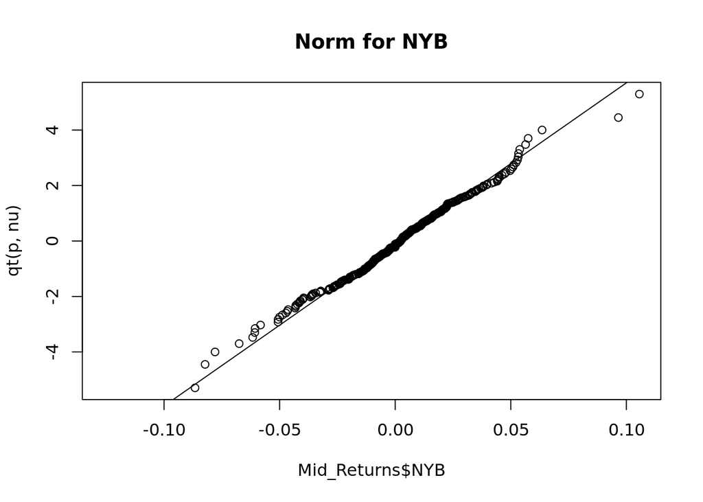

```r
p = (0:dim(Mid_Returns)[1]) / (dim(Mid_Returns)[1] + 1)
qqplot(Mid_Returns$NYB, qt(p, nu), main="Norm for NYB")
qqline(Mid_Returns$NYB, qt(p, nu))
```

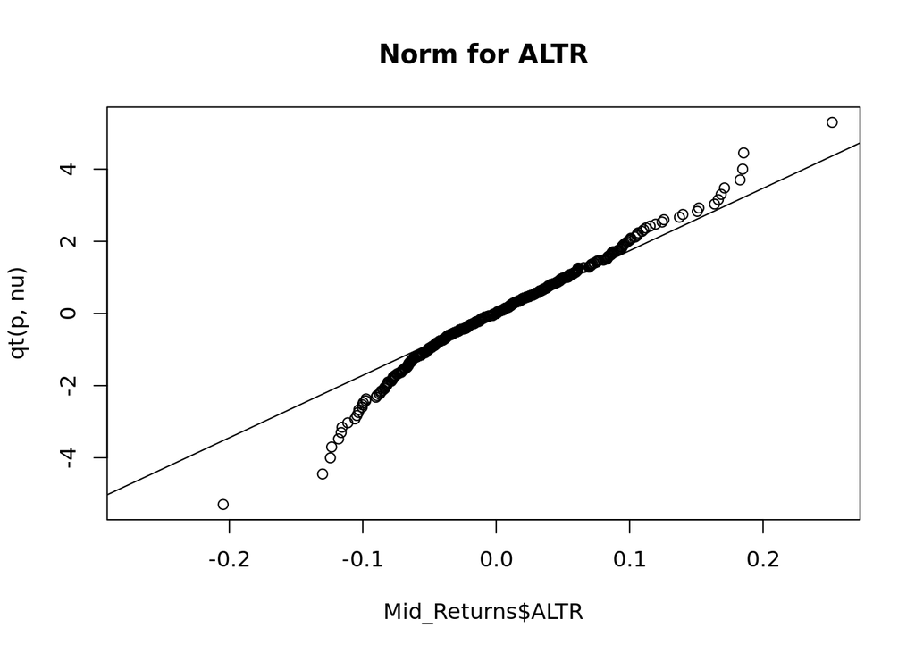

```r
qqplot(Mid_Returns$ALTR, qt(p, nu), main="Norm for ALTR")
qqline(Mid_Returns$ALTR, qt(p, nu))
```

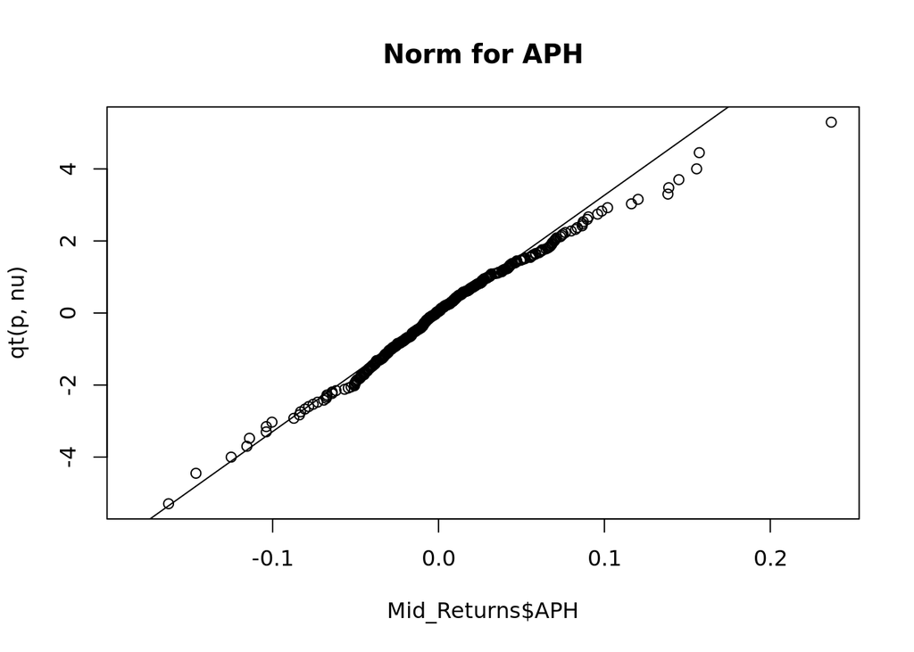

```r
qqplot(Mid_Returns$APH, qt(p, nu), main="Norm for APH")
qqline(Mid_Returns$APH, qt(p, nu))
```

4. It turns out the t-distribution can fit NYB and APH’s heavy tail well, but not so much for ALTR. I guess that because all variables are sharing the same tail when being fitted by a multivariate t-distribution.

```r
fitfinal = cov.trob(Mid_Returns, nu=nu)
aic_t <- -2 * sum(log(dmt(Mid_Returns, mean=fitfinal$center, S=fitfinal$cov, df=nu))) + 2 * (3 * 3)
aic_n <- -2 * sum(log(dmnorm(Mid_Returns, mean=colMeans(Mid_Returns), varcov=cov(Mid_Returns)))) + 2 * (3 * 3 + 1)
print(aic_t)
```

```
## [1] -5720.868
```

```r
print(aic_n)
```

```
## [1] -5551.348
```